# Ethical_Issues_AI_Assignment

[figure not shown]

**The following is the GitHub repository Link**

https://github.com/rafiaw01/M515R-Ethical-Issues-AI.git

**Name** : Awais Rafi

**Course Instructor** : Dr Reza

**Student Id** : GH1024169

**Submission Date** : April 03,2025

**Module Name** : M515R Ethical Issues

**Problem Introduction**

A client that specializes in Data Analytics is concerned that data analysis on highly sensitive data such as crime data or financial fraud data or income data across population demographics can be extremely biased towards a certain categorical attribute such as Ethnicity or background or location or marital status and causes unncessary reputation damages as well . Possibility could be being from Asia and always being flagged for credit card fraud just because the ML pipeline biasely predicts the output

Hence the following ML pipeline is built using the Biasenss methodolgy to challenge the Status quo

**The Initial step is to Install the relevant Libraries for further use**

```python
!pip install aequitas
```

```python
pip install dask[dataframe]
```

```python
import pandas as pd
from aequitas.group import Group
from aequitas.bias import Bias
from sklearn.model_selection import train_test_split
from sklearn.metrics import confusion_matrix
from sklearn.linear_model import LogisticRegression
from sklearn.metrics import accuracy_score
import numpy as np
import matplotlib.cm as colormaps
import matplotlib.pyplot as plt
from aequitas.fairness import Fairness
import missingno as ms
from sklearn.impute import SimpleImputer
from sklearn.model_selection import learning_curve
from sklearn.linear_model import LogisticRegression
```

**The following is the DataSet Link** ** https://www.kaggle.com/datasets/wenruliu/adult-income-dataset?resource=download **

**Once the relevant Libraries are Installed then the Dataset in the CSV format has to be uploaded**

```python
df = pd.read_csv("/content/adult.csv")
```

**Once the Dataset is uploaded then Data Processing has to be carried out**

```python
df.head()
```

|  | age | workclass | fnlwgt | education | educational-num | marital-status | occupation | relationship | race | gender | capital-gain | capital-loss | hours-per-week | native-country | income |
| --- | --- | --- | --- | --- | --- | --- | --- | --- | --- | --- | --- | --- | --- | --- | --- |
| 0 | 25 | Private | 226802 | 11th | 7 | Never-married | Machine-op-inspct | Own-child | Black | Male | 0 | 0 | 40 | United-States | <=50K |
| 1 | 38 | Private | 89814 | HS-grad | 9 | Married-civ-spouse | Farming-fishing | Husband | White | Male | 0 | 0 | 50 | United-States | <=50K |
| 2 | 28 | Local-gov | 336951 | Assoc-acdm | 12 | Married-civ-spouse | Protective-serv | Husband | White | Male | 0 | 0 | 40 | United-States | >50K |
| 3 | 44 | Private | 160323 | Some-college | 10 | Married-civ-spouse | Machine-op-inspct | Husband | Black | Male | 7688 | 0 | 40 | United-States | >50K |
| 4 | 18 | ? | 103497 | Some-college | 10 | Never-married | ? | Own-child | White | Female | 0 | 0 | 30 | United-States | <=50K |

```python
df.shape
```

```
(48842, 15)
```

```python
df.info()
```

```
<class 'pandas.core.frame.DataFrame'>
RangeIndex: 48842 entries, 0 to 48841
Data columns (total 15 columns):
 #   Column           Non-Null Count  Dtype
---  ------           --------------  -----
 0   age              48842 non-null  int64
 1   workclass        48842 non-null  object
 2   fnlwgt           48842 non-null  int64
 3   education        48842 non-null  object
 4   educational-num  48842 non-null  int64
 5   marital-status   48842 non-null  object
 6   occupation       48842 non-null  object
 7   relationship     48842 non-null  object
 8   race             48842 non-null  object
 9   gender           48842 non-null  object
 10  capital-gain     48842 non-null  int64
 11  capital-loss     48842 non-null  int64
 12  hours-per-week   48842 non-null  int64
 13  native-country   48842 non-null  object
 14  income           48842 non-null  object
dtypes: int64(6), object(9)
memory usage: 5.6+ MB
```

```python
df.describe()
```

|  | age | fnlwgt | educational-num | capital-gain | capital-loss | hours-per-week |
| --- | --- | --- | --- | --- | --- | --- |
| count | 48842.000000 | 4.884200e+04 | 48842.000000 | 48842.000000 | 48842.000000 | 48842.000000 |
| mean | 38.643585 | 1.896641e+05 | 10.078089 | 1079.067626 | 87.502314 | 40.422382 |
| std | 13.710510 | 1.056040e+05 | 2.570973 | 7452.019058 | 403.004552 | 12.391444 |
| min | 17.000000 | 1.228500e+04 | 1.000000 | 0.000000 | 0.000000 | 1.000000 |
| 25% | 28.000000 | 1.175505e+05 | 9.000000 | 0.000000 | 0.000000 | 40.000000 |
| 50% | 37.000000 | 1.781445e+05 | 10.000000 | 0.000000 | 0.000000 | 40.000000 |
| 75% | 48.000000 | 2.376420e+05 | 12.000000 | 0.000000 | 0.000000 | 45.000000 |
| max | 90.000000 | 1.490400e+06 | 16.000000 | 99999.000000 | 4356.000000 | 99.000000 |

```python
print(df.isnull())
```

```
         age  workclass  fnlwgt  education  educational-num  marital-status  \
0      False      False   False      False            False           False
1      False      False   False      False            False           False
2      False      False   False      False            False           False
3      False      False   False      False            False           False
4      False      False   False      False            False           False
...      ...        ...     ...        ...              ...             ...
48837  False      False   False      False            False           False
48838  False      False   False      False            False           False
48839  False      False   False      False            False           False
48840  False      False   False      False            False           False
48841  False      False   False      False            False           False

       occupation  relationship   race  gender  capital-gain  capital-loss  \
0           False         False  False   False         False         False
```

[output cut: 25 more lines]

**Considering that Using traditional Data Analysis Approach null values are found to be false however that is not the case and further data processing is required as follows**

```python
df_2 = df.copy()
df_2.head()
```

|  | age | workclass | fnlwgt | education | educational-num | marital-status | occupation | relationship | race | gender | capital-gain | capital-loss | hours-per-week | native-country | income |
| --- | --- | --- | --- | --- | --- | --- | --- | --- | --- | --- | --- | --- | --- | --- | --- |
| 0 | 25 | Private | 226802 | 11th | 7 | Never-married | Machine-op-inspct | Own-child | Black | Male | 0 | 0 | 40 | United-States | <=50K |
| 1 | 38 | Private | 89814 | HS-grad | 9 | Married-civ-spouse | Farming-fishing | Husband | White | Male | 0 | 0 | 50 | United-States | <=50K |
| 2 | 28 | Local-gov | 336951 | Assoc-acdm | 12 | Married-civ-spouse | Protective-serv | Husband | White | Male | 0 | 0 | 40 | United-States | >50K |
| 3 | 44 | Private | 160323 | Some-college | 10 | Married-civ-spouse | Machine-op-inspct | Husband | Black | Male | 7688 | 0 | 40 | United-States | >50K |
| 4 | 18 | ? | 103497 | Some-college | 10 | Never-married | ? | Own-child | White | Female | 0 | 0 | 30 | United-States | <=50K |

```python
df_2['workclass'].unique()
```

```
array(['Private', 'Local-gov', '?', 'Self-emp-not-inc', 'Federal-gov',
       'State-gov', 'Self-emp-inc', 'Without-pay', 'Never-worked'],
      dtype=object)
```

```python
df_2['occupation'].unique()
```

```
array(['Machine-op-inspct', 'Farming-fishing', 'Protective-serv', '?',
       'Other-service', 'Prof-specialty', 'Craft-repair', 'Adm-clerical',
       'Exec-managerial', 'Tech-support', 'Sales', 'Priv-house-serv',
       'Transport-moving', 'Handlers-cleaners', 'Armed-Forces'],
      dtype=object)
```

```python
df_2['native-country'].unique()
```

```
array(['United-States', '?', 'Peru', 'Guatemala', 'Mexico',
       'Dominican-Republic', 'Ireland', 'Germany', 'Philippines',
       'Thailand', 'Haiti', 'El-Salvador', 'Puerto-Rico', 'Vietnam',
       'South', 'Columbia', 'Japan', 'India', 'Cambodia', 'Poland',
       'Laos', 'England', 'Cuba', 'Taiwan', 'Italy', 'Canada', 'Portugal',
       'China', 'Nicaragua', 'Honduras', 'Iran', 'Scotland', 'Jamaica',
       'Ecuador', 'Yugoslavia', 'Hungary', 'Hong', 'Greece',
       'Trinadad&Tobago', 'Outlying-US(Guam-USVI-etc)', 'France',
       'Holand-Netherlands'], dtype=object)
```

```python
df_2['gender'].unique()
```

```
array(['Male', 'Female'], dtype=object)
```

```python
df_2['relationship'].unique()
```

```
array(['Own-child', 'Husband', 'Not-in-family', 'Unmarried', 'Wife',
       'Other-relative'], dtype=object)
```

```python
df_2.replace('?' , np.nan , inplace=True)
df_2.dropna(inplace=True)
df_2['occupation'].unique(),df_2['native-country'].unique(),df_2['workclass'].unique()
```

```
(array(['Machine-op-inspct', 'Farming-fishing', 'Protective-serv',
        'Other-service', 'Prof-specialty', 'Craft-repair', 'Adm-clerical',
        'Exec-managerial', 'Tech-support', 'Sales', 'Priv-house-serv',
        'Transport-moving', 'Handlers-cleaners', 'Armed-Forces'],
       dtype=object),
 array(['United-States', 'Peru', 'Guatemala', 'Mexico',
        'Dominican-Republic', 'Ireland', 'Germany', 'Philippines',
        'Thailand', 'Haiti', 'El-Salvador', 'Puerto-Rico', 'Vietnam',
        'South', 'Columbia', 'Japan', 'India', 'Cambodia', 'Poland',
        'Laos', 'England', 'Cuba', 'Taiwan', 'Italy', 'Canada', 'Portugal',
        'China', 'Nicaragua', 'Honduras', 'Iran', 'Scotland', 'Jamaica',
        'Ecuador', 'Yugoslavia', 'Hungary', 'Hong', 'Greece',
        'Trinadad&Tobago', 'Outlying-US(Guam-USVI-etc)', 'France',
        'Holand-Netherlands'], dtype=object),
 array(['Private', 'Local-gov', 'Self-emp-not-inc', 'Federal-gov',
        'State-gov', 'Self-emp-inc', 'Without-pay'], dtype=object))
```

```python
df_2.replace(['NaN',np.nan], '?', inplace=True)
df_2.dropna(how='any', inplace=True)
print(df_2['workclass'].unique())
```

```
['Private' 'Local-gov' 'Self-emp-not-inc' 'Federal-gov' 'State-gov'
 'Self-emp-inc' 'Without-pay']
```

```python
df_2.replace(['NaN',np.nan], '?', inplace=True)
df_2.dropna(how='any', inplace=True)
print(df_2['gender'].unique())
```

```
['Male' 'Female']
```

```python
df_2.replace(['NaN',np.nan], '?', inplace=True)
df_2.dropna(how='any', inplace=True)
print(df_2['relationship'].unique())
```

```
['Own-child' 'Husband' 'Not-in-family' 'Unmarried' 'Wife' 'Other-relative']
```

```python
df_2.replace(['NaN',np.nan], '?', inplace=True)
df_2.dropna(how='any', inplace=True)
print(df_2['occupation'].unique())
```

```
['Machine-op-inspct' 'Farming-fishing' 'Protective-serv' 'Other-service'
 'Prof-specialty' 'Craft-repair' 'Adm-clerical' 'Exec-managerial'
 'Tech-support' 'Sales' 'Priv-house-serv' 'Transport-moving'
 'Handlers-cleaners' 'Armed-Forces']
```

```python
df_2.replace(['NaN',np.nan], '?', inplace=True)
df_2.dropna(how='any', inplace=True)
print(df_2['marital-status'].unique())
```

```
['Never-married' 'Married-civ-spouse' 'Widowed' 'Separated' 'Divorced'
 'Married-spouse-absent' 'Married-AF-spouse']
```

```python
df_2.replace(['NaN',np.nan], '?', inplace=True)
df_2.dropna(how='any', inplace=True)
print(df_2['workclass'].unique())
```

```
['Private' 'Local-gov' 'Self-emp-not-inc' 'Federal-gov' 'State-gov'
 'Self-emp-inc' 'Without-pay']
```

**Then comes feature Engineering Process**

**Converting Categorical Values into Numerical Values**

```python
df_2.loc[df['native-country']!='United-States','native-country'] ='US'
```

```python
df_2.loc[df['native-country']!='United-States','native-country'] ='Non-US'
```

```python
NON_US_LABEL, US_LABEL = (1,0)
```

```python
df_2['native-country'] = df_2['native-country'].map({'United-States':US_LABEL,'Non-US':NON_US_LABEL}).fillna(-1).astype(int)
```

```python
df_2.head()
```

|  | age | workclass | fnlwgt | education | educational-num | marital-status | occupation | relationship | race | gender | capital-gain | capital-loss | hours-per-week | native-country | income |
| --- | --- | --- | --- | --- | --- | --- | --- | --- | --- | --- | --- | --- | --- | --- | --- |
| 0 | 25 | Private | 226802 | 11th | 7 | Never-married | Machine-op-inspct | Own-child | Black | Male | 0 | 0 | 40 | 0 | <=50K |
| 1 | 38 | Private | 89814 | HS-grad | 9 | Married-civ-spouse | Farming-fishing | Husband | White | Male | 0 | 0 | 50 | 0 | <=50K |
| 2 | 28 | Local-gov | 336951 | Assoc-acdm | 12 | Married-civ-spouse | Protective-serv | Husband | White | Male | 0 | 0 | 40 | 0 | >50K |
| 3 | 44 | Private | 160323 | Some-college | 10 | Married-civ-spouse | Machine-op-inspct | Husband | Black | Male | 7688 | 0 | 40 | 0 | >50K |
| 5 | 34 | Private | 198693 | 10th | 6 | Never-married | Other-service | Not-in-family | White | Male | 0 | 0 | 30 | 0 | <=50K |

**The following step will convert Occupation Column to Numerical values using One Hot Encoding**

```python
job_map = dict((value, key) for (key, value) in enumerate(df_2.occupation.unique()))
df_2['occupation'] = df_2['occupation'].map(job_map)
df_2 = pd.get_dummies(df_2, columns=['occupation'])
df_2.head()
```

|  | age | workclass | fnlwgt | education | educational-num | marital-status | relationship | race | gender | capital-gain | ... | occupation_4 | occupation_5 | occupation_6 | occupation_7 | occupation_8 | occupation_9 | occupation_10 | occupation_11 | occupation_12 | occupation_13 |
| --- | --- | --- | --- | --- | --- | --- | --- | --- | --- | --- | --- | --- | --- | --- | --- | --- | --- | --- | --- | --- | --- |
| 0 | 25 | Private | 226802 | 11th | 7 | Never-married | Own-child | Black | Male | 0 | ... | False | False | False | False | False | False | False | False | False | False |
| 1 | 38 | Private | 89814 | HS-grad | 9 | Married-civ-spouse | Husband | White | Male | 0 | ... | False | False | False | False | False | False | False | False | False | False |
| 2 | 28 | Local-gov | 336951 | Assoc-acdm | 12 | Married-civ-spouse | Husband | White | Male | 0 | ... | False | False | False | False | False | False | False | False | False | False |
| 3 | 44 | Private | 160323 | Some-college | 10 | Married-civ-spouse | Husband | Black | Male | 7688 | ... | False | False | False | False | False | False | False | False | False | False |
| 5 | 34 | Private | 198693 | 10th | 6 | Never-married | Not-in-family | White | Male | 0 | ... | False | False | False | False | False | False | False | False | False | False |

5 rows × 28 columns

**Converting capital gained and loss in capital to categorical values**

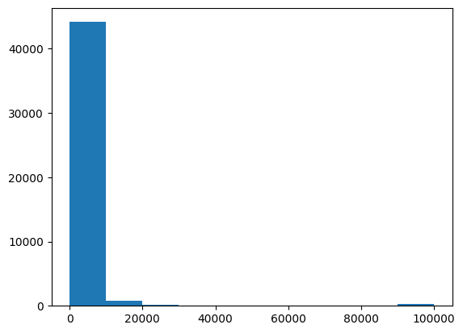

```python
cap_loss, cap_gain, =df_2['capital-loss'], df_2['capital-gain']
plt.hist(cap_gain,bins=None,density=False)
plt.show()
```

```python
df_2.loc[(df_2['capital-gain'] > 0),'capital-gain'] = 1
df_2.loc[(df_2['capital-gain'] == 0 ,'capital-gain')]= 0
df_2.head()
```

|  | age | workclass | fnlwgt | education | educational-num | marital-status | relationship | race | gender | capital-gain | ... | occupation_4 | occupation_5 | occupation_6 | occupation_7 | occupation_8 | occupation_9 | occupation_10 | occupation_11 | occupation_12 | occupation_13 |
| --- | --- | --- | --- | --- | --- | --- | --- | --- | --- | --- | --- | --- | --- | --- | --- | --- | --- | --- | --- | --- | --- |
| 0 | 25 | Private | 226802 | 11th | 7 | Never-married | Own-child | Black | Male | 0 | ... | False | False | False | False | False | False | False | False | False | False |
| 1 | 38 | Private | 89814 | HS-grad | 9 | Married-civ-spouse | Husband | White | Male | 0 | ... | False | False | False | False | False | False | False | False | False | False |
| 2 | 28 | Local-gov | 336951 | Assoc-acdm | 12 | Married-civ-spouse | Husband | White | Male | 0 | ... | False | False | False | False | False | False | False | False | False | False |
| 3 | 44 | Private | 160323 | Some-college | 10 | Married-civ-spouse | Husband | Black | Male | 1 | ... | False | False | False | False | False | False | False | False | False | False |
| 5 | 34 | Private | 198693 | 10th | 6 | Never-married | Not-in-family | White | Male | 0 | ... | False | False | False | False | False | False | False | False | False | False |

5 rows × 28 columns

```python
df_2.loc[(df_2['capital-loss'] > 0),'capital-loss'] = 1
df_2.loc[(df_2['capital-loss'] == 0 ,'capital-loss')]= 0
df_2.head()
```

|  | age | workclass | fnlwgt | education | educational-num | marital-status | relationship | race | gender | capital-gain | ... | occupation_4 | occupation_5 | occupation_6 | occupation_7 | occupation_8 | occupation_9 | occupation_10 | occupation_11 | occupation_12 | occupation_13 |
| --- | --- | --- | --- | --- | --- | --- | --- | --- | --- | --- | --- | --- | --- | --- | --- | --- | --- | --- | --- | --- | --- |
| 0 | 25 | Private | 226802 | 11th | 7 | Never-married | Own-child | Black | Male | 0 | ... | False | False | False | False | False | False | False | False | False | False |
| 1 | 38 | Private | 89814 | HS-grad | 9 | Married-civ-spouse | Husband | White | Male | 0 | ... | False | False | False | False | False | False | False | False | False | False |
| 2 | 28 | Local-gov | 336951 | Assoc-acdm | 12 | Married-civ-spouse | Husband | White | Male | 0 | ... | False | False | False | False | False | False | False | False | False | False |
| 3 | 44 | Private | 160323 | Some-college | 10 | Married-civ-spouse | Husband | Black | Male | 1 | ... | False | False | False | False | False | False | False | False | False | False |
| 5 | 34 | Private | 198693 | 10th | 6 | Never-married | Not-in-family | White | Male | 0 | ... | False | False | False | False | False | False | False | False | False | False |

5 rows × 28 columns

**Furthermore Categorical Values such as Sex and Salary will be converted to Binary Values to ease in building a Pipeline**

```python
MALE_LABEL , FEMALE_LABEL = (0, 1)
LOW_INCOME_LABEL , HIGH_INCOME_LABEL = (0, 1)
```

```python
print(df_2['gender'].unique())
```

```
['Male' 'Female']
```

```python
df_2['income'] = df_2['income'].map({'>50K':HIGH_INCOME_LABEL,'<=50K':LOW_INCOME_LABEL})
df_2['gender'] = df_2['gender'].map({'Male':MALE_LABEL,'Female':FEMALE_LABEL})
df_2.head()
```

|  | age | workclass | fnlwgt | education | educational-num | marital-status | relationship | race | gender | capital-gain | ... | occupation_4 | occupation_5 | occupation_6 | occupation_7 | occupation_8 | occupation_9 | occupation_10 | occupation_11 | occupation_12 | occupation_13 |
| --- | --- | --- | --- | --- | --- | --- | --- | --- | --- | --- | --- | --- | --- | --- | --- | --- | --- | --- | --- | --- | --- |
| 0 | 25 | Private | 226802 | 11th | 7 | Never-married | Own-child | Black | 0 | 0 | ... | False | False | False | False | False | False | False | False | False | False |
| 1 | 38 | Private | 89814 | HS-grad | 9 | Married-civ-spouse | Husband | White | 0 | 0 | ... | False | False | False | False | False | False | False | False | False | False |
| 2 | 28 | Local-gov | 336951 | Assoc-acdm | 12 | Married-civ-spouse | Husband | White | 0 | 0 | ... | False | False | False | False | False | False | False | False | False | False |
| 3 | 44 | Private | 160323 | Some-college | 10 | Married-civ-spouse | Husband | Black | 0 | 1 | ... | False | False | False | False | False | False | False | False | False | False |
| 5 | 34 | Private | 198693 | 10th | 6 | Never-married | Not-in-family | White | 0 | 0 | ... | False | False | False | False | False | False | False | False | False | False |

5 rows × 28 columns

**The Dataset contains Column of Race and has categorical values and needs to be converted**

```python
racial_map={' White':1,' Amer-Indian-Eskimo':4,' Asian-Pac-Islander':2,' Black':0,' Other':2}
df_2['race']= df['race'].map(racial_map)


df_2 = pd.get_dummies(df_2, columns=['race'])
df_2.head()
```

|  | age | workclass | fnlwgt | education | educational-num | marital-status | relationship | gender | capital-gain | capital-loss | ... | occupation_4 | occupation_5 | occupation_6 | occupation_7 | occupation_8 | occupation_9 | occupation_10 | occupation_11 | occupation_12 | occupation_13 |
| --- | --- | --- | --- | --- | --- | --- | --- | --- | --- | --- | --- | --- | --- | --- | --- | --- | --- | --- | --- | --- | --- |
| 0 | 25 | Private | 226802 | 11th | 7 | Never-married | Own-child | 0 | 0 | 0 | ... | False | False | False | False | False | False | False | False | False | False |
| 1 | 38 | Private | 89814 | HS-grad | 9 | Married-civ-spouse | Husband | 0 | 0 | 0 | ... | False | False | False | False | False | False | False | False | False | False |
| 2 | 28 | Local-gov | 336951 | Assoc-acdm | 12 | Married-civ-spouse | Husband | 0 | 0 | 0 | ... | False | False | False | False | False | False | False | False | False | False |
| 3 | 44 | Private | 160323 | Some-college | 10 | Married-civ-spouse | Husband | 0 | 1 | 0 | ... | False | False | False | False | False | False | False | False | False | False |
| 5 | 34 | Private | 198693 | 10th | 6 | Never-married | Not-in-family | 0 | 0 | 0 | ... | False | False | False | False | False | False | False | False | False | False |

5 rows × 27 columns

**The dataset has Categorial Column of Marital Status and needs to be converted to Couple or Single as to reduce data noise as ML pipeline is built**

```python
df_2['marital-status'].unique()
```

```
array(['Never-married', 'Married-civ-spouse', 'Widowed', 'Separated',
       'Divorced', 'Married-spouse-absent', 'Married-AF-spouse'],
      dtype=object)
```

```python
df_2['marital-status'] = df_2['marital-status'].replace([' Married-spouse-absent','Divorced','Separated','Never-married','Widowed'],'Single')
df_2['marital-status'] = df_2['marital-status'].replace(['Married-civ-spouse','Married-AF-spouse'],'Couple')
df_2.head()
```

|  | age | workclass | fnlwgt | education | educational-num | marital-status | relationship | gender | capital-gain | capital-loss | ... | occupation_4 | occupation_5 | occupation_6 | occupation_7 | occupation_8 | occupation_9 | occupation_10 | occupation_11 | occupation_12 | occupation_13 |
| --- | --- | --- | --- | --- | --- | --- | --- | --- | --- | --- | --- | --- | --- | --- | --- | --- | --- | --- | --- | --- | --- |
| 0 | 25 | Private | 226802 | 11th | 7 | Single | Own-child | 0 | 0 | 0 | ... | False | False | False | False | False | False | False | False | False | False |
| 1 | 38 | Private | 89814 | HS-grad | 9 | Couple | Husband | 0 | 0 | 0 | ... | False | False | False | False | False | False | False | False | False | False |
| 2 | 28 | Local-gov | 336951 | Assoc-acdm | 12 | Couple | Husband | 0 | 0 | 0 | ... | False | False | False | False | False | False | False | False | False | False |
| 3 | 44 | Private | 160323 | Some-college | 10 | Couple | Husband | 0 | 1 | 0 | ... | False | False | False | False | False | False | False | False | False | False |
| 5 | 34 | Private | 198693 | 10th | 6 | Single | Not-in-family | 0 | 0 | 0 | ... | False | False | False | False | False | False | False | False | False | False |

5 rows × 27 columns

```python
COUPLE_LABEL, SINGLE_LABEL = (0, 1)
df_2['marital-status'] = df_2['marital-status'].map({'Couple':COUPLE_LABEL,'Single':SINGLE_LABEL})
df_2.head()
```

|  | age | workclass | fnlwgt | education | educational-num | marital-status | relationship | gender | capital-gain | capital-loss | ... | occupation_4 | occupation_5 | occupation_6 | occupation_7 | occupation_8 | occupation_9 | occupation_10 | occupation_11 | occupation_12 | occupation_13 |
| --- | --- | --- | --- | --- | --- | --- | --- | --- | --- | --- | --- | --- | --- | --- | --- | --- | --- | --- | --- | --- | --- |
| 0 | 25 | Private | 226802 | 11th | 7 | 1.0 | Own-child | 0 | 0 | 0 | ... | False | False | False | False | False | False | False | False | False | False |
| 1 | 38 | Private | 89814 | HS-grad | 9 | 0.0 | Husband | 0 | 0 | 0 | ... | False | False | False | False | False | False | False | False | False | False |
| 2 | 28 | Local-gov | 336951 | Assoc-acdm | 12 | 0.0 | Husband | 0 | 0 | 0 | ... | False | False | False | False | False | False | False | False | False | False |
| 3 | 44 | Private | 160323 | Some-college | 10 | 0.0 | Husband | 0 | 1 | 0 | ... | False | False | False | False | False | False | False | False | False | False |
| 5 | 34 | Private | 198693 | 10th | 6 | 1.0 | Not-in-family | 0 | 0 | 0 | ... | False | False | False | False | False | False | False | False | False | False |

5 rows × 27 columns

**Furthermore to enhance the quality of the pipeline the following step is needed as well - This converts Relationships to Binary Values as ML for further processing**

```python
rltnship_map = {'Unmarried':3,'Wife':2,'Husband':1,'Not-in-family':4,'Own-child':0,'Other-relative':5}
df_2['relationship'] = df_2['relationship'].map(rltnship_map)
df_2.head(10)
```

|  | age | workclass | fnlwgt | education | educational-num | marital-status | relationship | gender | capital-gain | capital-loss | ... | occupation_4 | occupation_5 | occupation_6 | occupation_7 | occupation_8 | occupation_9 | occupation_10 | occupation_11 | occupation_12 | occupation_13 |
| --- | --- | --- | --- | --- | --- | --- | --- | --- | --- | --- | --- | --- | --- | --- | --- | --- | --- | --- | --- | --- | --- |
| 0 | 25 | Private | 226802 | 11th | 7 | 1.0 | 0 | 0 | 0 | 0 | ... | False | False | False | False | False | False | False | False | False | False |
| 1 | 38 | Private | 89814 | HS-grad | 9 | 0.0 | 1 | 0 | 0 | 0 | ... | False | False | False | False | False | False | False | False | False | False |
| 2 | 28 | Local-gov | 336951 | Assoc-acdm | 12 | 0.0 | 1 | 0 | 0 | 0 | ... | False | False | False | False | False | False | False | False | False | False |
| 3 | 44 | Private | 160323 | Some-college | 10 | 0.0 | 1 | 0 | 1 | 0 | ... | False | False | False | False | False | False | False | False | False | False |
| 5 | 34 | Private | 198693 | 10th | 6 | 1.0 | 4 | 0 | 0 | 0 | ... | False | False | False | False | False | False | False | False | False | False |
| 7 | 63 | Self-emp-not-inc | 104626 | Prof-school | 15 | 0.0 | 1 | 0 | 1 | 0 | ... | True | False | False | False | False | False | False | False | False | False |
| 8 | 24 | Private | 369667 | Some-college | 10 | 1.0 | 3 | 1 | 0 | 0 | ... | False | False | False | False | False | False | False | False | False | False |
| 9 | 55 | Private | 104996 | 7th-8th | 4 | 0.0 | 1 | 0 | 0 | 0 | ... | False | True | False | False | False | False | False | False | False | False |
| 10 | 65 | Private | 184454 | HS-grad | 9 | 0.0 | 1 | 0 | 1 | 0 | ... | False | False | False | False | False | False | False | False | False | False |
| 11 | 36 | Federal-gov | 212465 | Bachelors | 13 | 0.0 | 1 | 0 | 0 | 0 | ... | False | False | True | False | False | False | False | False | False | False |

10 rows × 27 columns

```python
df_2 = pd.get_dummies(df_2, columns=['relationship'])
df_2.head()
```

|  | age | workclass | fnlwgt | education | educational-num | marital-status | gender | capital-gain | capital-loss | hours-per-week | ... | occupation_10 | occupation_11 | occupation_12 | occupation_13 | relationship_0 | relationship_1 | relationship_2 | relationship_3 | relationship_4 | relationship_5 |
| --- | --- | --- | --- | --- | --- | --- | --- | --- | --- | --- | --- | --- | --- | --- | --- | --- | --- | --- | --- | --- | --- |
| 0 | 25 | Private | 226802 | 11th | 7 | 1.0 | 0 | 0 | 0 | 40 | ... | False | False | False | False | True | False | False | False | False | False |
| 1 | 38 | Private | 89814 | HS-grad | 9 | 0.0 | 0 | 0 | 0 | 50 | ... | False | False | False | False | False | True | False | False | False | False |
| 2 | 28 | Local-gov | 336951 | Assoc-acdm | 12 | 0.0 | 0 | 0 | 0 | 40 | ... | False | False | False | False | False | True | False | False | False | False |
| 3 | 44 | Private | 160323 | Some-college | 10 | 0.0 | 0 | 1 | 0 | 40 | ... | False | False | False | False | False | True | False | False | False | False |
| 5 | 34 | Private | 198693 | 10th | 6 | 1.0 | 0 | 0 | 0 | 30 | ... | False | False | False | False | False | False | False | False | True | False |

5 rows × 32 columns

**The next step is converting or categorizing workclass column into private or nopay or government**

```python
def cluster_workclass(x):
    if x['workclass'] == 'Local-gov' or x['workclass']== 'Federal-gov' or x['workclass']==' State-gov': return 'govt'
    elif x['workclass'] == ' Private':return 'private'
    elif x['workclass'] == ' Self-emp-not-inc' or x['workclass'] == 'Self-emp-inc': return 'self_employed'
    else: return 'without_pay'

df_2['workclass']=df_2.apply(cluster_workclass, axis=1)

df_2['workclass'] = df_2['workclass'].map({'govt':1,'private':0,'self_employed':3,'without_pay':2})
df_2 = pd.get_dummies(df_2, columns=['workclass'])
df_2.head()
```

|  | age | fnlwgt | education | educational-num | marital-status | gender | capital-gain | capital-loss | hours-per-week | native-country | ... | occupation_13 | relationship_0 | relationship_1 | relationship_2 | relationship_3 | relationship_4 | relationship_5 | workclass_1 | workclass_2 | workclass_3 |
| --- | --- | --- | --- | --- | --- | --- | --- | --- | --- | --- | --- | --- | --- | --- | --- | --- | --- | --- | --- | --- | --- |
| 0 | 25 | 226802 | 11th | 7 | 1.0 | 0 | 0 | 0 | 40 | 0 | ... | False | True | False | False | False | False | False | False | True | False |
| 1 | 38 | 89814 | HS-grad | 9 | 0.0 | 0 | 0 | 0 | 50 | 0 | ... | False | False | True | False | False | False | False | False | True | False |
| 2 | 28 | 336951 | Assoc-acdm | 12 | 0.0 | 0 | 0 | 0 | 40 | 0 | ... | False | False | True | False | False | False | False | True | False | False |
| 3 | 44 | 160323 | Some-college | 10 | 0.0 | 0 | 1 | 0 | 40 | 0 | ... | False | False | True | False | False | False | False | False | True | False |
| 5 | 34 | 198693 | 10th | 6 | 1.0 | 0 | 0 | 0 | 30 | 0 | ... | False | False | False | False | False | True | False | False | True | False |

5 rows × 34 columns

**Next step is to Predict the Income of an Individual without biasing**

```python
contns_features = ['fnlwgt','age' ,'hours-per-week', 'educational-num',]
X = df_2[contns_features]
df_2[contns_features] = (X - np.mean(X))/ np.std(X)
df_2.head()
```

|  | age | fnlwgt | education | educational-num | marital-status | gender | capital-gain | capital-loss | hours-per-week | native-country | ... | occupation_13 | relationship_0 | relationship_1 | relationship_2 | relationship_3 | relationship_4 | relationship_5 | workclass_1 | workclass_2 | workclass_3 |
| --- | --- | --- | --- | --- | --- | --- | --- | --- | --- | --- | --- | --- | --- | --- | --- | --- | --- | --- | --- | --- | --- |
| 0 | -3588.445667 | 1.697740 | 11th | -18586.689191 | 1.0 | 0 | 0 | 0 | -3948.913300 | 0 | ... | False | True | False | False | False | False | False | False | True | False |
| 1 | -3587.462139 | 0.400972 | HS-grad | -18585.905754 | 0.0 | 0 | 0 | 0 | -3948.080479 | 0 | ... | False | False | True | False | False | False | False | False | True | False |
| 2 | -3588.218699 | 2.740442 | Assoc-acdm | -18584.730598 | 0.0 | 0 | 0 | 0 | -3948.913300 | 0 | ... | False | False | True | False | False | False | False | True | False | False |
| 3 | -3587.008203 | 1.068431 | Some-college | -18585.514035 | 0.0 | 0 | 1 | 0 | -3948.913300 | 0 | ... | False | False | True | False | False | False | False | False | True | False |
| 5 | -3587.764763 | 1.431652 | 10th | -18587.080910 | 1.0 | 0 | 0 | 0 | -3949.746122 | 0 | ... | False | False | False | False | False | True | False | False | True | False |

5 rows × 34 columns

```python
df_2 = df_2.drop(['education'], axis=1)
```

**The next step is crucial and important for ML Pipeline to progress and that is training the ML ALgorithm as follows using a Classifier**

```python
# MLPC stands for MultiLayer Perceptron Classifier  (MLPC) that is used for Classification Problems

from sklearn.neural_network import MLPClassifier
from sklearn.model_selection import train_test_split
```

```python
def work_dataset(df_2):
    data_mix = df_2.sample(frac=1).reset_index(drop=True)
    X = data_mix.drop(['income'], axis=1)
    y = data_mix['income']

    imputer = SimpleImputer(strategy='mean')
    X = imputer.fit_transform(X)

    # The Test_Size is taken to be 25% (0.25) of the dataset as it is a normal approach

    x_train, x_test, y_train, y_test = train_test_split(X, y, test_size=0.25)
    return (x_train, y_train), (x_test, y_test)
```

```python
MLP_MAX_ITER=1000      # The Iterations is setto 1000 the possible addition could be to use 10000 if needed
```

```python
(x_train, y_train), (x_test, y_test) = work_dataset(df_2)
model = MLPClassifier(max_iter=MLP_MAX_ITER)
model.fit(x_train,y_train)
prediction = model.predict(x_test)
```

**Algorithm Performance**

```python
test_df = pd.DataFrame(x_test.copy())
test_df['income'] = y_test.values
test_df['pred'] = pd.Series(prediction, index=test_df.index)
test_df['accurate'] = (test_df['pred'] == test_df['income'])

test_df.head()
```

|  | 0 | 1 | 2 | 3 | 4 | 5 | 6 | 7 | 8 | 9 | ... | 25 | 26 | 27 | 28 | 29 | 30 | 31 | income | pred | accurate |
| --- | --- | --- | --- | --- | --- | --- | --- | --- | --- | --- | --- | --- | --- | --- | --- | --- | --- | --- | --- | --- | --- |
| 0 | -3587.008203 | 3.181022 | -18585.905754 | 0.0 | 0.0 | 0.0 | 0.0 | -3947.247657 | 0.0 | 0.0 | ... | 0.0 | 0.0 | 0.0 | 0.0 | 0.0 | 0.0 | 1.0 | 1 | 1 | True |
| 1 | -3587.764763 | 1.350791 | -18585.905754 | 1.0 | 1.0 | 0.0 | 0.0 | -3949.579557 | 0.0 | 0.0 | ... | 0.0 | 1.0 | 0.0 | 0.0 | 0.0 | 1.0 | 0.0 | 0 | 0 | True |
| 2 | -3588.445667 | 0.481142 | -18584.338880 | 1.0 | 0.0 | 0.0 | 0.0 | -3948.913300 | 0.0 | 0.0 | ... | 0.0 | 0.0 | 0.0 | 0.0 | 0.0 | 1.0 | 0.0 | 0 | 0 | True |
| 3 | -3587.462139 | 1.127709 | -18584.338880 | 1.0 | 1.0 | 0.0 | 0.0 | -3947.664068 | 0.0 | 0.0 | ... | 0.0 | 0.0 | 1.0 | 0.0 | 0.0 | 1.0 | 0.0 | 0 | 0 | True |
| 4 | -3587.462139 | 2.689873 | -18585.514035 | 1.0 | 1.0 | 0.0 | 0.0 | -3948.330325 | 0.0 | 0.0 | ... | 0.0 | 0.0 | 1.0 | 0.0 | 1.0 | 0.0 | 0.0 | 0 | 0 | True |

5 rows × 35 columns

```python
"Accuracy of The Classifier as follows : ", test_df.accurate.mean()
```

```
('Accuracy of The Classifier as follows : ', np.float64(0.7423491951176366))
```

```
('The Overall accuracy of the Model  is: ', np.float64(0.6666666666666666)) {}
('Accuracy Across Gender Attribute is as follows  ',) {}
('P(((high, HIGH) or (low, LOW)) |', 'Male', '): ', np.float64(0.6666666666666666)) {}
('P(((high, HIGH) or (low, LOW)) |', 'Female', '): ', np.float64(0.6666666666666666)) {}
Positive Rate
('P(high|', 'Female', '): ', np.float64(0.6666666666666666)) {}
('P(high|', 'Male', '): ', np.float64(0.3333333333333333)) {}
Negative Rate
('P(low|', 'Female', '): ', np.float64(0.3333333333333333)) {}
('P(low|', 'Male', '): ', np.float64(0.6666666666666666)) {}
('\n4. True positive and True negative rates',) {}
('\n4.i', ' True positive and negative rates on sex=Female', '\n') {}
('P((high, HIGH)| HIGH,Female)', ': ', np.float64(1.0)) {}
('P((low, LOW)| LOW,Female)', ':', np.float64(0.5)) {}
('\n4.ii', ' True positive and negative rates on sex=Male', '\n') {}
('P((high, HIGH)| HIGH,Male)', ': ', np.float64(0.5)) {}
('P((low, LOW)| LOW,Male)', ':', np.float64(1.0)) {}
```

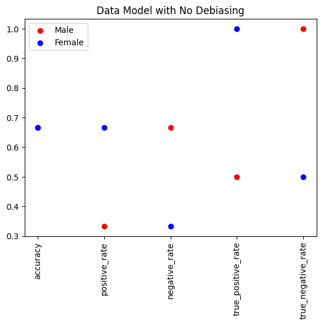

[output not shown]

```python
# The Following code prints out a Chart with No-Debiasing in the Dataset



LOW_SALARY_LABEL = 0
FEMALE_LABEL = 0
HIGH_SALARY_LABEL = 1
MALE_LABEL = 1

def gender_evaluation(results_df, print_stats=False):


    def _print(*args, **kwargs):
        if print_stats:
            print(args, kwargs)

    summaries = {}
    overall_accuracy = results_df.accurate.mean()
    summaries['accuracy_overall'] = overall_accuracy

    _print("The Overall accuracy of the Model  is: ", overall_accuracy)


    # Now is to find Accuracy using Gender Attribute

    _print("Accuracy Across Gender Attribute is as follows  ")

    for gender in [(MALE_LABEL, "Male"), (FEMALE_LABEL, "Female")]:
        rows = results_df[results_df.gender == gender[0]]
        gender_accuracy = rows.accurate.mean()
        summaries['accuracy_' + gender[1]] = gender_accuracy
        _print("P(((high, HIGH) or (low, LOW)) |", gender[1], "): ", gender_accuracy)


    # High Income Rate for Gender

    print("Positive Rate")

    for gender in [(FEMALE_LABEL, "Female"), (MALE_LABEL, "Male")]:
        rows = results_df[results_df.gender == gender[0]]
        positive_rate_for_gender = (rows['pred'] == HIGH_SALARY_LABEL).mean()
        summaries['positive_rate_' + gender[1]] = positive_rate_for_gender
        _print("P(high|", gender[1], "): ", positive_rate_for_gender)


    #Low Income Rate for Gender

    print("Negative Rate")

    for gender in [(FEMALE_LABEL, "Female"), (MALE_LABEL, "Male")]:
        rows = results_df[results_df.gender == gender[0]]
        negative_rate_for_gender = (rows['pred'] == LOW_SALARY_LABEL).mean() #fixed name
        summaries['negative_rate_' + gender[1]] = negative_rate_for_gender
        _print("P(low|", gender[1], "): ", negative_rate_for_gender) #fixed name


    _print("\n4. True positive and True negative rates")



    for index, gender in enumerate([(FEMALE_LABEL, "Female"), (MALE_LABEL, "Male")]):
        _print("\n4." + ("i") * (1 + index), " True positive and negative rates on sex=" + gender[1], "\n")
        rows = results_df[results_df.gender == gender[0]]

        high_income = rows[rows.salary == HIGH_SALARY_LABEL]
        low_income = rows[rows.salary == LOW_SALARY_LABEL]
        if high_income.shape[0] > 0:
            assert high_income.salary.mean() == HIGH_SALARY_LABEL, "high_mean: " + str(high_income.salary.mean())
        if low_income.shape[0] > 0:
            assert low_income.salary.mean() == LOW_SALARY_LABEL, "low_mean: " + str(low_income.salary.mean())

        high_pred = rows[rows.pred == HIGH_SALARY_LABEL]
        low_pred = rows[rows.pred == LOW_SALARY_LABEL]
        if high_pred.shape[0] > 0:
            assert high_pred.pred.mean() == HIGH_SALARY_LABEL, "high_pred_mean: " + str(high_pred.pred.mean())
        if low_pred.shape[0] > 0:
            assert low_pred.pred.mean() == LOW_SALARY_LABEL, "low_pred_mean: " + str(low_pred.pred.mean())


        true_positive_rate = high_income.accurate.mean()
        true_negative_rate = low_income.accurate.mean()
        summaries['true_positive_rate_' + gender[1]] = true_positive_rate
        summaries['true_negative_rate_' + gender[1]] = true_negative_rate

        _print(str.format("P((high, HIGH)| HIGH,{0})", gender[1]), ": ", true_positive_rate)
        _print(str.format("P((low, LOW)| LOW,{0})", gender[1]), ":", true_negative_rate)



    return summaries

def group_performance(accuracy_results, title, fignum=1, rotation='horizontal', labels=["Male", "Female"]):
    assert isinstance(accuracy_results, list), "Accuracy results must be a list"
    indices = [0]
    colors = ['red', 'blue']
    fig, ax = plt.subplots()
    for index in indices:
        ax.scatter(index, accuracy_results[0][index], c=colors[0], label=labels[0] if labels and index == 0 else None)
        ax.scatter(index, accuracy_results[1][index], c=colors[1], label=labels[1] if labels and index == 0 else None)
    if labels:
        ax.legend()
    plt.title(title)
    plt.show()


def group_comparison(approaches, accuracy_results, title, fignum=1, rotation='horizontal', labels=["Male", "Female"]):
    assert isinstance(accuracy_results, list), "Accuracy results must be a list"
    indices = list(range(len(approaches)))
    colors = ['red', 'blue']
    fig, ax = plt.subplots()
    for index in indices:
        ax.scatter(index, accuracy_results[0][index], c=colors[0], label=labels[0] if labels and index == 0 else None)
        ax.scatter(index, accuracy_results[1][index], c=colors[1], label=labels[1] if labels and index == 0 else None)
    if labels:
        ax.legend()
    plt.xticks(indices, approaches, rotation=rotation)
    plt.title(title)
    plt.show()


def gender_matrix(_feature, _summaries, _modelNames, _title, rotation='vertical'):
    gender_metrics = [[summary[_feature + '_Male'] for summary in _summaries],
                      [summary[_feature + '_Female'] for summary in _summaries]]
    group_comparison(_modelNames, gender_metrics, _title, rotation=rotation)



def summary_model(model_name, title, summary):
    summaries = []
    model_names = []
    for key in ["accuracy", "positive_rate", "negative_rate", "true_positive_rate", "true_negative_rate"]:
        new_summary = {"accuracy_Male": summary[key + "_Male"], "accuracy_Female": summary[key + "_Female"]}
        summaries.append(new_summary)
        model_names.append(key)
    gender_matrix("accuracy", summaries, model_names, model_name)


# Data that will be used for Plotting

data = {
    'gender': [FEMALE_LABEL, MALE_LABEL, FEMALE_LABEL, MALE_LABEL, FEMALE_LABEL, MALE_LABEL],
    'pred': [HIGH_SALARY_LABEL, HIGH_SALARY_LABEL, LOW_SALARY_LABEL, LOW_SALARY_LABEL, HIGH_SALARY_LABEL, LOW_SALARY_LABEL],
    'salary': [HIGH_SALARY_LABEL, HIGH_SALARY_LABEL, LOW_SALARY_LABEL, LOW_SALARY_LABEL, LOW_SALARY_LABEL, HIGH_SALARY_LABEL],
    'accurate': [True, True, True, True, False, False]
}
results_df = pd.DataFrame(data)


summary = gender_evaluation(results_df, print_stats=True)
summary_model("Data Model with No Debiasing", "Model Performance", summary)


print(summary)
```

**A learning Curve has to be plotted**

```
lrxtrn shape: (50000, 10)
lrytrn shape: (50000,)
lrxtrn dtypes: 0    float64
1    float64
2    float64
3    float64
4    float64
5    float64
6    float64
7    float64
8    float64
9    float64
dtype: object
lrytrn dtype: int64
lxtrn has NaN: False
lxtrn has inf: False
lrytrn has NaN: False
lrytrn has inf: False
```

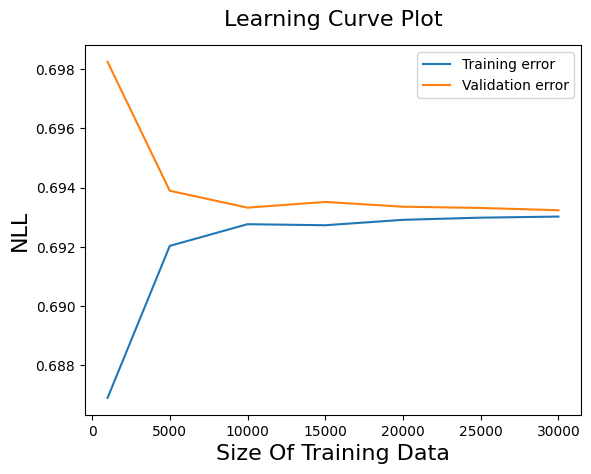

```python
from sklearn.model_selection import learning_curve
from sklearn.linear_model import LogisticRegression
import numpy as np
import matplotlib.pyplot as plt


# The following are standard training sizes that are commonly used for DataAnalysis

train_sizes = [1000, 5000, 10000, 15000, 20000, 25000, 30000, 35000, 40000, 45000]

def plt_lrng_crve(estimator, lxtrn, lrytrn, train_sizes, title=None):
    real_train_sizes = []
    for size in train_sizes:
        if size <= lxtrn.shape[0] * 0.60:
            real_train_sizes.append(size)
        else:
            break

# The following code checks the shape sizes with a try and exception feature as well

    print("lrxtrn shape:", lxtrn.shape)
    print("lrytrn shape:", lrytrn.shape)
    print("lrxtrn dtypes:", lxtrn.dtypes)
    print("lrytrn dtype:", lrytrn.dtype)


    print("lxtrn has NaN:", lxtrn.isnull().values.any())
    print("lxtrn has inf:", np.isinf(lxtrn.values).any())
    print("lrytrn has NaN:", pd.isnull(lrytrn).any())
    print("lrytrn has inf:", np.isinf(lrytrn.values).any())

    try:
        if not real_train_sizes:
          print("Warning PLease Select Training Size")
          return

        train_sizes, train_scores, validation_scores = learning_curve(
            estimator, lxtrn, lrytrn, train_sizes=real_train_sizes, scoring='neg_log_loss'
        )
        train_scores_mean = -train_scores.mean(axis=1)
        validation_scores_mean = -validation_scores.mean(axis=1)

        plt.plot(train_sizes, train_scores_mean, label='Training error')
        plt.plot(train_sizes, validation_scores_mean, label='Validation error')

        plt.ylabel('NLL', fontsize=16)
        plt.xlabel('Size Of Training Data', fontsize=16)
        plt.title(title, fontsize=16, y=1.03)
        plt.legend()
        plt.show()
    except Exception as e:
        print(f"Error generating Learning Curve: {e}")


# The following line of code checks the random seed data
np.random.seed(40)
lrxtrain = pd.DataFrame(np.random.rand(50000, 10))
lrytrain = pd.Series(np.random.randint(0, 2, 50000))


# The estimator that will be used is LogisticRegression with a solver called LibLinear
# Liblinear counts as largescale linear classification

estimator = LogisticRegression(solver='liblinear')

plt_lrng_crve(estimator, lrxtrain, lrytrain, train_sizes, title='Learning Curve Plot')
```

**Introduction of biaseness in a ML model are as follows and are of two types Through unawareness of dataset**

```python
def dataset(df_2):
    (x_train, y_train), (x_test, y_test) = work_dataset(df_2)

    x_train = pd.DataFrame(x_train, columns=df_2.drop('income', axis=1).columns)
    x_test = pd.DataFrame(x_test, columns=df_2.drop('income' , axis=1).columns)
    testdata = x_test.copy()

    # The below line of Code is to check if gender attribute is present
    # Or not

    if 'gender' not in testdata.columns:
        # If 'gender' attribute is mssing in the testing data if it is in df_2 then  copy it
        if 'gender' in df_2.columns:
            testdata['gender'] = df_2['gender']
        # If 'gender' is missing then provide a default value such as 0
        else:
            testdata['gender'] = 0

    return (x_train, y_train), (x_test, y_test), testdata
```

```python
# Once the Above code succesfully runs then further the MLPC classifier wil be used



from sklearn.neural_network import MLPClassifier


predictor = MLPClassifier(max_iter=MLP_MAX_ITER, verbose=True)
(x_train, ytrain), (x_test, y_test), testdata = dataset(df_2)
predictor.fit(x_train, y_train)
```

[output not shown]

```
MLPClassifier(max_iter=1000, verbose=True)
```

```python
def predictor_performance(predictor, x_test, y_test ,df):

    testdata = x_test.copy()
    testdata['income'] = y_test
    testdata['pred'] = pd.Series(predictor, index=x_test.index)
    testdata['accurate'] = (testdata['pred'] == testdata['income'])
    # The original dataframe df might not have the column 'gender'
    # Instead of using merge, directly assign the gender column from df_2 if it exists.
    if 'gender' in df_2.columns:
        testdata['gender'] = df_2['gender']
    else:
        # Handle the case where 'gender' is not in df_2.
        # You might want to raise an error or assign a default value.
        testdata['gender'] = 0  # For example, assign 0 as a default value

    # Adding this line to create the 'salary' column from the 'income' column
    testdata['salary'] = testdata['income']

    return gender_evaluation(testdata)
```

**Analyzing Performance of The Predictor**

```
Positive Rate
Negative Rate
```

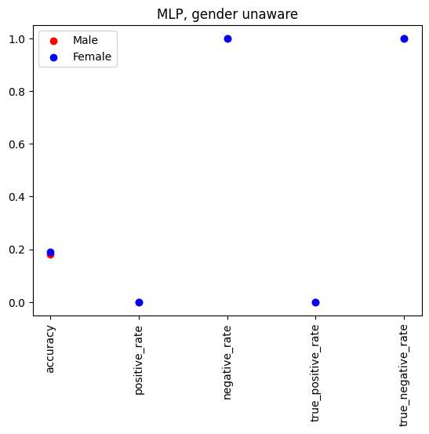

```python
predictns = predictor.predict(x_test)
method_1 = predictor_performance(predictns, testdata, y_test,df)
summary_model("MLP, gender unaware", "", method_1)
```

**Through DataSet Balancing**

```python
def predictor_performance(predictor, x_test, y_test ,df):


    if isinstance(x_test, np.ndarray):
        x_test = pd.DataFrame(x_test, columns=df.drop('income', axis=1).columns)

    testdata = x_test.copy()
    testdata['income'] = y_test.values  # Use .values to get underlying NumPy array
    testdata['pred'] = pd.Series(predictor, index=testdata.index)  # Use testdata.index
    testdata['accurate'] = (testdata['pred'] == testdata['income'])

    # Reseting the  the index of testing data before using .loc method
    testdata = testdata.reset_index(drop=True)


    df_2_reset = df_2.reset_index(drop=True)

    if 'gender' in df_2_reset.columns:
        # Access 'gender' from df_2 using the reset index of testdata
        testdata['gender'] = df_2_reset.loc[testdata.index, 'gender'].values
    else:

        testdata['gender'] = 0


    testdata['salary'] = testdata['income']

    return gender_evaluation(testdata)
```

```python
df_3 = df_2.copy()
df_3.head()
```

|  | age | fnlwgt | educational-num | marital-status | gender | capital-gain | capital-loss | hours-per-week | native-country | income | ... | occupation_13 | relationship_0 | relationship_1 | relationship_2 | relationship_3 | relationship_4 | relationship_5 | workclass_1 | workclass_2 | workclass_3 |
| --- | --- | --- | --- | --- | --- | --- | --- | --- | --- | --- | --- | --- | --- | --- | --- | --- | --- | --- | --- | --- | --- |
| 0 | -3588.445667 | 1.697740 | -18586.689191 | 1.0 | 0 | 0 | 0 | -3948.913300 | 0 | 0 | ... | False | True | False | False | False | False | False | False | True | False |
| 1 | -3587.462139 | 0.400972 | -18585.905754 | 0.0 | 0 | 0 | 0 | -3948.080479 | 0 | 0 | ... | False | False | True | False | False | False | False | False | True | False |
| 2 | -3588.218699 | 2.740442 | -18584.730598 | 0.0 | 0 | 0 | 0 | -3948.913300 | 0 | 1 | ... | False | False | True | False | False | False | False | True | False | False |
| 3 | -3587.008203 | 1.068431 | -18585.514035 | 0.0 | 0 | 1 | 0 | -3948.913300 | 0 | 1 | ... | False | False | True | False | False | False | False | False | True | False |
| 5 | -3587.764763 | 1.431652 | -18587.080910 | 1.0 | 0 | 0 | 0 | -3949.746122 | 0 | 0 | ... | False | False | False | False | False | True | False | False | True | False |

5 rows × 33 columns

**Datapoints per demographic by category**

```python
def get_gender_category_balanced_dataset(dataset, test_size=0.25):


    males = dataset[(dataset.gender==MALE_LABEL)]
    females = dataset[(dataset.gender==FEMALE_LABEL)]
    male_high = males[(males.income == HIGH_SALARY_LABEL)]
    male_low = males[(males.income == LOW_SALARY_LABEL)]
    female_high = females[(females.income == HIGH_SALARY_LABEL)]
    female_low = females[(females.income == LOW_SALARY_LABEL)]


    smallest = min((x.shape[0] for x in [male_high, male_low, female_high, female_low]))


    _male_high = male_high.sample(n=smallest).reset_index(drop=True)
    _male_low = male_low.sample(n=smallest).reset_index(drop=True)
    _female_high = female_high.sample(n=smallest).reset_index(drop=True)
    _female_low = female_low.sample(n=smallest).reset_index(drop=True)
    _combined = pd.concat([_male_high, _male_low, _female_high, _female_low]).sample(frac=1).reset_index(drop=True)

    Xvals=_combined.drop(["income"], axis=1)
    Yvals = _combined["income"]


    imputer = SimpleImputer(strategy='mean')
    Xvals = imputer.fit_transform(Xvals)

    x_train, x_test, y_train, y_test = train_test_split(Xvals, Yvals, test_size=test_size)
    return (x_train, y_train), (x_test, y_test)
```

```python
(x_train, y_train), (x_test, y_test) = get_gender_category_balanced_dataset(df_3)
x_train.shape, x_test.shape
```

```
((5007, 32), (1669, 32))
```

```
Iteration 1, loss = 17.67636002
Iteration 2, loss = 16.89076008
Iteration 3, loss = 16.30889444
Iteration 4, loss = 12.13052802
Iteration 5, loss = 5.49332824
Iteration 6, loss = 9.47832267
Iteration 7, loss = 9.13863780
Iteration 8, loss = 5.31836900
Iteration 9, loss = 12.36700535
Iteration 10, loss = 9.92069895
Iteration 11, loss = 7.12608323
Iteration 12, loss = 11.41982456
Iteration 13, loss = 15.47823647
Iteration 14, loss = 6.03660189
Iteration 15, loss = 8.45510350
Iteration 16, loss = 14.05607308
Iteration 17, loss = 8.95623440
Iteration 18, loss = 10.36911684
Iteration 19, loss = 5.37238640
Training loss did not improve more than tol=0.000100 for 10 consecutive epochs. Stopping.
Positive Rate
Negative Rate
```

[figure not shown]

```python
PredictionErrorDisplay = MLPClassifier(max_iter=MLP_MAX_ITER)
predictor.fit(x_train, y_train)



approach_2 = predictor_performance(predictor.predict(x_test), x_test, y_test, df_3)
summary_model("MLP, Equal DataPoints ", "", approach_2)
```

```python
(x_train, y_train), (x_test, y_test) = get_gender_category_balanced_dataset(df_3)

predictor = MLPClassifier(max_iter=MLP_MAX_ITER)
predictor.fit(x_train, y_train)
predictions = predictor.predict(x_test)
```

```
Positive Rate
Negative Rate
```

[figure not shown]

```python
approach_3 = predictor_performance(predictions, x_test, y_test, df_3)
summary_model("MLP, Equal DataPoints per Category", "", approach_3)
```

**Discussion**

The above ML pipeline uses three different data testing features through gender unwareness , using equal data points and equal data points per category as well .

It can be deduced that with all the three use cases different results were achieved